# Technology and Social Change

Lecture 5: The Printing Press

Bogdan G. Popescu

bgpopescu@tec.mx

Tecnológico de Monterrey

# Introduction

## Before We Begin

### A Puzzle

Around 1450, a single technology — the movable-type press — became available across Europe and the Islamic world.

- **Same machine**. Same basic inputs. Same potential.

Yet the outcomes diverged radically:

- In the **Dutch Republic**, presses multiplied freely and book prices collapsed

## Before We Begin

### A Puzzle

Around 1450, a single technology — the movable-type press — became available across Europe and the Islamic world.

- **Same machine**. Same basic inputs. Same potential.

Yet the outcomes diverged radically:

- In **England**, printing fueled a scientific revolution

## Before We Begin

### A Puzzle

Around 1450, a single technology — the movable-type press — became available across Europe and the Islamic world.

- **Same machine**. Same basic inputs. Same potential.

Yet the outcomes diverged radically:

- In the **Ottoman Empire**, Arabic-script printing was banned for **nearly 300 years**

## Before We Begin

### A Puzzle

Around 1450, a single technology — the movable-type press — became available across Europe and the Islamic world.

- **Same machine**. Same basic inputs. Same potential.

**Why did identical technology produce such different outcomes across polities?**

## Johannes Gutenberg (c. 1400–1468)

- Born in **Mainz**, trained as a goldsmith
- Developed **movable metal type**, oil-based ink, and the wooden screw press (~1440)
- Printed the **Gutenberg Bible** (c. 1455) — ~180 copies, 42 lines per page
- Died in relative obscurity; his financier Johann Fust seized the press in a lawsuit

[figure not shown]

Idealized portrait of Johannes Gutenberg (16th c.). No contemporary likeness survives. Source: Wikimedia Commons (public domain).

## Learning Objectives

By the end of this lecture, you will be able to:

1. Explain why the printing press was **disruptive**
2. Describe the **economic mechanisms** of knowledge markets
3. Analyze how information reshaped **social structures**
4. Apply a **political economy framework** to technology
5. Interpret **empirical evidence** on long-run effects

## Roadmap

1. The technology: what constraints did it relax?
2. Economic changes: knowledge markets and literacy
3. Social and political effects
4. Winners, losers, and institutional resistance
5. Evidence and modern parallels

# I. The Technology

## What Was the Printing Press?

### Gutenberg’s movable-type press (~1440, Mainz)

- **Movable metal type**: reusable letters cast in lead alloy
- **Oil-based ink**: better adhesion to metal type
- **Wooden screw press**: adapted from wine and olive presses
- **Standardized paper**: far cheaper than parchment

None of these was entirely new — the **combination** was revolutionary.

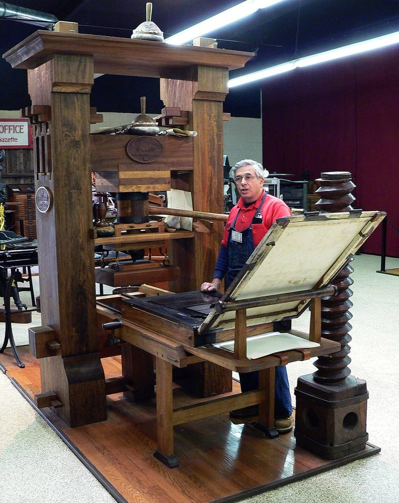

Reconstruction of a Gutenberg-era press. Source: Wikimedia Commons (public domain).

## Why Was It Disruptive?

### Disruption = dramatic change in cost structure

**Before the press**

- Marginal cost ≈ fixed cost (scribe labor)
- ~1 book per scribe per year (for a Bible)
- Natural monopoly: monasteries, scriptoria

**After the press**

- High fixed cost but **near-zero marginal cost**
- ~500 copies per press run
- Competitive market: any entrepreneur could enter

## Case Evidence: The Gutenberg Press

[video not shown]

Source: https://www.youtube.com/watch?v=aWU2iJzU3AA

1. Why is the hand mold called “the single unique element” of Gutenberg’s invention — why was it more important than the press itself?  
2. The punch took a full day to carve, and Gutenberg needed 270+. What does this reveal about the relationship between innovation and upfront investment?  
3. Why does Fry describe identical, mass-produced letters as “the greatest revolution since the invention of fire”?

## The Economics of Disruption

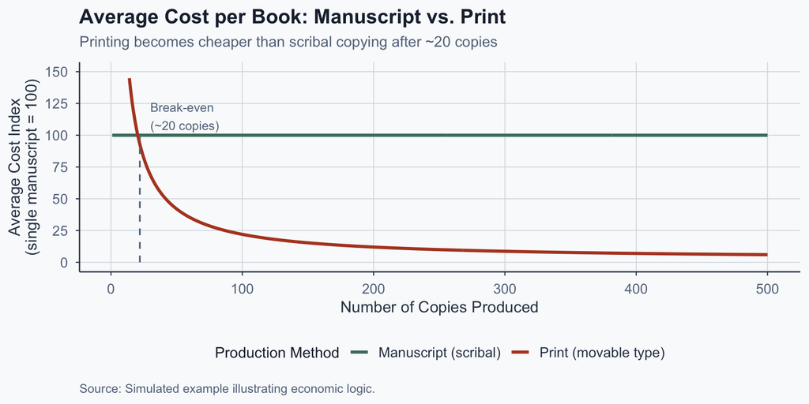

Figure 1: Printing beats scribal copying after ~20 copies.

## What Constraints Did It Relax?

| Constraint | Before Press | After Press |
| --- | --- | --- |
| **Reproduction cost** | Months of scribe labor | Hours of press work |
| **Accuracy** | Copyist errors accumulate | Identical copies |
| **Scale** | One copy at a time | Hundreds per run |
| **Access** | Monasteries, courts | Urban workshops, markets |
| **Language** | Latin (elite) | Vernacular editions emerge |

The press **democratized reproduction** — but not everywhere equally.

## So What?

### The press changed the *cost structure* of knowledge

- Fixed costs replaced variable costs → economies of scale
- Any literate entrepreneur could become a publisher
- This restructured the **entire market for ideas**

**Next**: What happened when ideas became cheap?

# II. Economic Changes

## The Knowledge Market Before Print

### A market with extreme barriers to entry

- **Supply**: scriptoria — few, slow producers
- **Demand**: Church, universities, patrons — few buyers
- **Prices**: extremely high → books as luxury goods
- **Result**: thin market, no incentive to expand literacy

This was a **stable equilibrium** — and the press broke it.

[figure not shown]

A scribe in a scriptorium (15th c., Jean Le Tavernier). Each book was copied by hand — months of labor per volume. Source: Wikimedia Commons (public domain).

## How the Press Changed Market Structure

### From monopoly to competition

1. **Entry barriers fell**: a press was affordable for urban entrepreneurs
2. **Output exploded**: ~20 million volumes printed by 1500
3. **Prices collapsed**: fell ~80% within 50 years
4. **Variety expanded**: printers published what sold

> The press created the first **mass market for ideas**.

## The Spread of Printing Across Europe

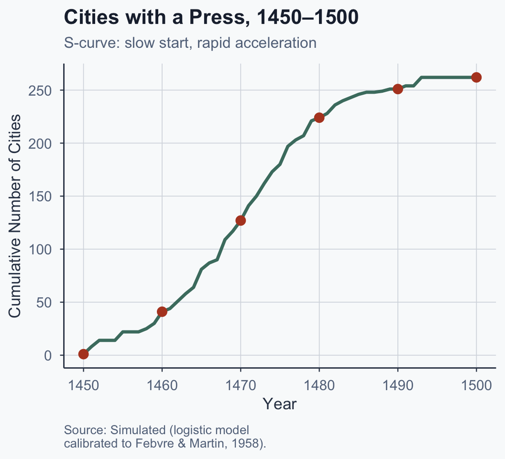

Figure 2: Adoption followed a classic S-curve pattern.

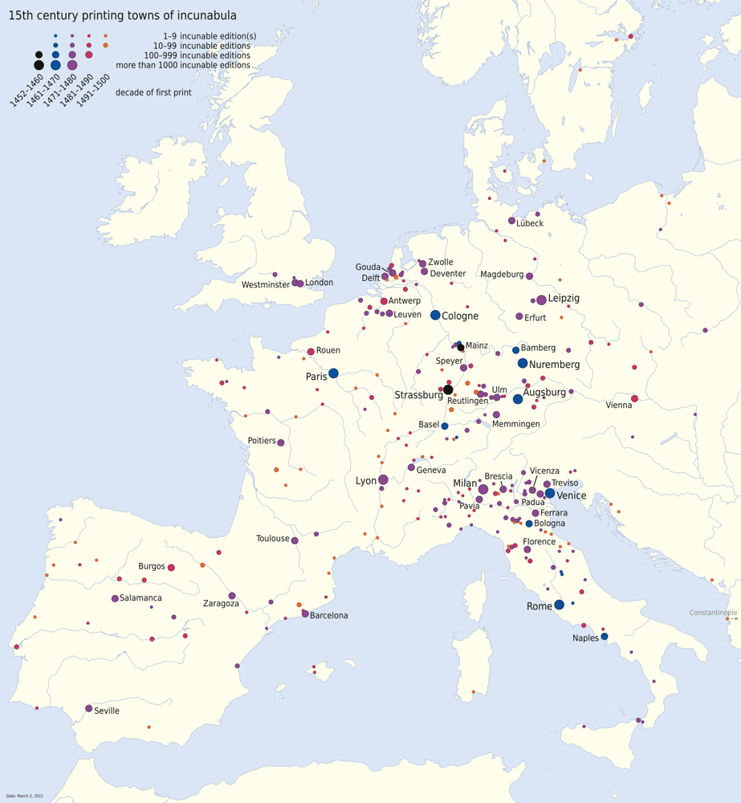

Printing towns in Europe during the incunabula period (before 1500). Source: Wikimedia Commons (public domain).

## The Literacy Feedback Loop

### Lower prices → more readers → more demand → more books

```
%%{init: {"flowchart": {"useMaxWidth": true, "nodeSpacing": 50, "rankSpacing": 70, "width": 1150, "height": 650}, "themeVariables": {"fontSize": "22px", "primaryColor": "#4a7c6f", "primaryTextColor": "#1e293b", "lineColor": "#334155"}}}%%
flowchart LR
    A["Press Lowers<br/>Book Cost"] --> B["More People<br/>Find Reading<br/>Worthwhile"]
    B --> C["Larger<br/>Reading Public"]
    C --> D["Demand for<br/>More Titles"]
    D --> E["Printers Produce<br/>More → Costs Fall"]
    E --> A
```

This **positive feedback loop** drove exponential growth in book production and literacy.

## Book Production Over Time

[figure not shown]

Figure 3: Output grew exponentially after introduction of movable type.

# III. Social and Political Effects

## Information Dissemination

### The press changed *who* could say *what* to *whom*

**Before the press:**

- Information flowed through **hierarchical channels**
- The Church monopolized large-scale communication
- Dissent was local and easily suppressed

**After the press:**

- Pamphlets reached thousands in **days**
- Luther’s pamphlets: ~400,000 copies printed by 1520
- Authorities could no longer control the narrative

## The Reformation as a Case Study

### The press as accelerant of religious change

- Luther **deliberately** wrote in German, not Latin
- 1518–1525: ~6 million pamphlets in German lands
- Cities **with presses** adopted Protestantism faster

> *“Printing is God’s highest and extremest act of grace.”* — Attributed to Martin Luther

[figure not shown]

Martin Luther (1528), by Lucas Cranach the Elder. Luther used the printing press to bypass Church gatekeepers and reach a mass audience. Source: Wikimedia Commons (public domain).

## The Reformation as a Case Study

### The press as accelerant of religious change

The Reformation was not *caused* by the press — but **hard to imagine without it**.

[figure not shown]

Martin Luther (1528), by Lucas Cranach the Elder. Luther used the printing press to bypass Church gatekeepers and reach a mass audience. Source: Wikimedia Commons (public domain).

## Social Mobility

### The press created new economic roles

| New Role | Description |
| --- | --- |
| **Printer** | Entrepreneur-craftsman; capital, not birth |
| **Bookseller** | Commercial intermediary in urban networks |
| **Author** | Could earn income directly from writing |
| **Translator** | Bridged Latin scholarship and vernacular |
| **Editor** | Curated knowledge for emerging markets |

The press created a new **middle class of knowledge workers**.

## Power Structures

### Shifting the balance of power

**Lost control:**

- Catholic Church (doctrine monopoly)
- Scribes and copyists (labor replaced)
- Monarchs (censorship became harder)

**Gained influence:**

- Protestant reformers
- Urban merchant class
- Vernacular intellectuals
- Printers as new gatekeepers

## Causal Framework: Press → Social Change

```
%%{init: {"flowchart": {"useMaxWidth": true, "nodeSpacing": 30, "rankSpacing": 50, "width": 1150, "height": 650}, "themeVariables": {"fontSize": "20px", "primaryColor": "#4a7c6f", "primaryTextColor": "#1e293b", "lineColor": "#334155"}}}%%
flowchart LR
    A["Printing<br/>Press"] --> B["Lower Book<br/>Prices"]
    A --> C["Information<br/>Access"]
    B --> D["Literacy &<br/>Human Capital"]
    D --> C
    C --> E["Reformation"]
    D --> F["Economic<br/>Growth"]
    E --> G["Political<br/>Change"]
    F --> G
    D --> H["Social<br/>Mobility"]
    F --> H
```

**Multiple causal channels**: direct information access, literacy-driven human capital, and the Reformation as a mediator.

## So What?

### The press reshuffled power across Europe

- New information channels bypassed traditional gatekeepers
- New economic roles created a knowledge middle class
- Every winner created a corresponding loser with an incentive to fight back

**Next**: What happens when the losers have the power to block the technology?

# IV. Political Economy: Winners and Losers

## A Political Economy Framework

### Every technology creates winners and losers — losers fight back

1. **Adoption is not automatic** — it needs institutional tolerance
2. **Incumbents** who lose will try to **block** the technology
3. **Diffusion speed** depends on the balance of power
4. **Institutions** shape who wins and who loses

> The printing press is a textbook case of this framework.

## Winners and Losers

| Group | Effect | Mechanism |
| --- | --- | --- |
| Printers & publishers | **Winner** | New profitable industry |
| Merchants & middle class | **Winner** | Cheaper commercial knowledge |
| Protestant reformers | **Winner** | Mass pamphlet dissemination |
| Vernacular authors | **Winner** | Audiences without Church patronage |
| Scribes & copyists | **Loser** | Labor replaced by machines |
| Catholic Church | **Loser** | Lost doctrinal monopoly |
| Monarchs | **Mixed** | Used press but faced censorship limits |

**Pattern**: urban commercial groups gained; information monopolists lost.

## The Knowledge Trap

### How actors shape information infrastructure — and development

```
%%{init: {"flowchart": {"useMaxWidth": true, "nodeSpacing": 40, "rankSpacing": 60}, "themeVariables": {"fontSize": "20px", "primaryColor": "#4a7c6f", "primaryTextColor": "#1e293b", "lineColor": "#334155"}}}%%
flowchart LR
    R["Rulers"] --> I["Information<br/>Infrastructure"]
    RA["Religious<br/>Authorities"] --> I
    SG["Scribal<br/>Groups"] --> I
    I --> H["Households"]
    I --> L["Literacy"]
    H --> L
    L --> D["Long-run<br/>Development"]

    style R fill:#e2e8f0,stroke:#64748b,color:#1e293b
    style RA fill:#e2e8f0,stroke:#64748b,color:#1e293b
    style SG fill:#e2e8f0,stroke:#64748b,color:#1e293b
    style H fill:#e2e8f0,stroke:#64748b,color:#1e293b
    style I fill:#4a7c6f,stroke:#334155,color:#fff
    style L fill:#4a7c6f,stroke:#334155,color:#fff
    style D fill:#4a7c6f,stroke:#334155,color:#fff
```

When **rulers**, **religious authorities**, and **scribal guilds** all have incentives to block information infrastructure, a knowledge trap persists for centuries.

## Case Study: The Ottoman Empire

### Why resist the press for nearly 290 years?

- Jewish & Armenian presses operated in Istanbul from the **1490s**
- Arabic-script printing banned until **1729** (Ibrahim Müteferrika)
- Even Müteferrika’s press was shut down after his death
- This was not ignorance — it was **political economy**

[figure not shown]

Ottoman scribes at work. Scribal guilds had strong incentives to resist the press. Source: Wikimedia Commons (public domain).

## The Ottoman Blocking Coalition

### Three veto players, one outcome

**1. Scribal guilds (*hattatlar*)**

- Tens of thousands of calligraphers in Istanbul
- Organized guild with **direct access** to the imperial court
- Quran copying was both livelihood and sacred duty

## The Ottoman Blocking Coalition

### Three veto players, one outcome

**2. The *ulema* (religious scholars)**

- Controlled education, law, and doctrinal interpretation
- Printing sacred Arabic script declared sacrilegious
- Real concern: printed books bypass their **gatekeeper role**
- *Şeyhülislam* could issue **fatwas** blocking innovations

## The Ottoman Blocking Coalition

### Three veto players, one outcome

**3. The Sultanate’s patronage logic**

- Sultan depended on *ulema* for **legitimacy**, guilds for **urban order**
- Both groups received stipends, tax exemptions, and status
- Adopters (merchants, intellectuals) had **no voice** at the Porte

## The Ottoman Blocking Coalition

### Three veto players, one outcome

**The calculus**: losers were organized, powerful, and inside the palace. Winners were diffuse and outside it.

## The Ottoman Case: Consequences

### What 290 years of blocking cost

| Indicator | Ottoman Empire | Western Europe |
| --- | --- | --- |
| First Arabic-script press | 1729 | 1450s |
| Books published by 1800 | ~500 titles | Millions of titles |
| Literacy rate (c. 1800) | ~2–3% | 30–60% (varies) |
| Universities (c. 1800) | Madrasas (static curriculum) | Research universities emerging |

**Lesson**: technology does not diffuse on its merits — it diffuses where **institutions allow it**.

## Case Study: England vs. France

### Same technology, different institutional responses

**England**

- Printing arrived 1476 (Caxton)
- Crown initially supportive
- Stationers’ Company: guild but market-driven
- Press relatively free after 1695

**France**

- Printing arrived 1470 (Paris)
- Heavy royal and Church censorship
- Index of Forbidden Books enforced
- *Philosophes* used underground presses

**Result**: England’s open knowledge market contributed to earlier industrialization.

## Institutional Openness to Print

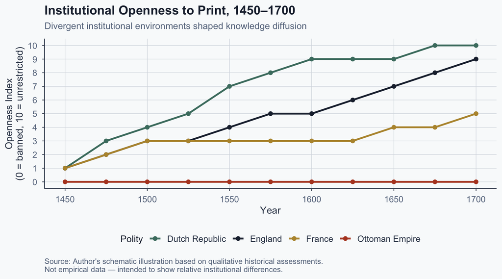

Figure 4: Institutional environments diverged sharply across polities.

## Censorship and Resistance

### The political economy of information control

- **Index Librorum Prohibitorum** (1559): Church banned book list
- **Licensing Acts** (England, 1538–1695): pre-publication censorship
- **Book burnings**: symbolic but often ineffective

Censorship is costly to enforce and creates **smuggling incentives**:

- Banned books printed in tolerant jurisdictions
- Prohibition often **increased demand**

## So What?

### Institutions determined whether technology could transform society

- Where incumbents blocked the press, adoption stalled
- Where institutions were permissive, knowledge markets flourished
- Can we **measure** these effects empirically?

**Next**: What does the evidence show — and what are the modern parallels?

# V. Evidence and Modern Parallels

## Empirical Evidence: Dittmar (2011)

### “Information Technology and Economic Change”

**Question**: Did the press *cause* city growth, or did growing cities adopt it first?

**Identification**: **distance from Mainz** as instrument for early adoption

- Closer cities adopted earlier for geographic, not economic, reasons
- Proximity plausibly exogenous to future growth trajectory

**Findings**:

- Press cities grew **~60% faster** (1500–1600)
- Robust to pre-existing city size, location, institutions
- Mechanism: human capital + commercial activity

## City Growth: Press vs. No Press

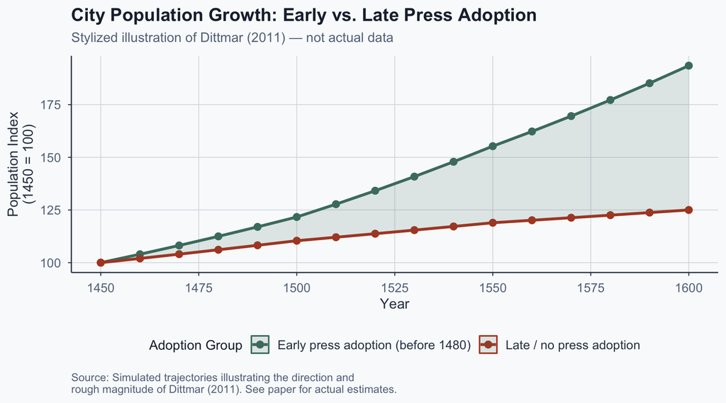

Figure 5: Stylized illustration of Dittmar’s (2011) main finding: early press cities grew substantially faster.

## Long-Run Effects: Becker & Woessmann (2009)

### “Was Weber Wrong?”

**Question**: Did the Reformation — spread by the press — persistently affect human capital?

**Identification**: **distance from Wittenberg** as instrument for Protestant adoption

- Closer counties became Protestant earlier
- Compare literacy outcomes **centuries later** (1870s Prussian county data)

## Long-Run Effects: Becker & Woessmann (2009)

### “Was Weber Wrong?”

**Question**: Did the Reformation — spread by the press — persistently affect human capital?

**Finding**:

- Counties closer to Wittenberg had significantly **higher literacy in the 1870s**
- Mechanism: Protestant emphasis on reading scripture → persistent **human capital advantage**
- Effect persists **four centuries** after the Reformation

## Long-Run Effects: Rubin (2014)

### “Printing and Protestants”

**Question**: Was it the press itself, or the Reformation, that drove long-run change?

**Identification**: interaction of **press adoption × institutional environment**

- Press predicted Protestant adoption — but **only where authorities didn’t block it**
- In cities under strong Church/imperial control, the press had **no effect**

**Punchline**: technology is necessary but not sufficient — **institutions are the binding constraint**

## Modern Parallels: The Internet as “New Printing Press”

| Dimension | Printing Press (1450) | Internet (1990s) |
| --- | --- | --- |
| Reproduction cost | Near zero (after setup) | Near zero |
| Gatekeepers displaced | Church, scribes | Legacy media, publishers |
| New intermediaries | Printers, booksellers | Platforms, search engines |
| Censorship tool | *Index Librorum Prohibitorum* | Content moderation, algorithmic suppression, state firewalls |
| Market structure | Fragmented, competitive | Network effects → platform monopoly (winner-take-all) |
| Resistance coalition | *Ulema*, scribal guilds, Church hierarchy | Incumbent media, regulators, authoritarian states |

## Class Exercise

### Modern Incumbents and Resisters

**Prompt**: Think of a modern technology where incumbents are currently trying to block or slow adoption.

1. Who are the **incumbents** and what are they protecting?
2. Who are the **adopters** and what do they gain?
3. What **institutional mechanisms** are being used to resist?

**Time**: 5 minutes — discuss with your neighbor, then share.

# Conclusion

## Summary: Key Takeaways

1. The press was **disruptive**: it collapsed knowledge reproduction costs
2. It created **mass markets for ideas**: lower prices, wider access
3. It shifted power from clerical elites to urban middle classes
4. **Institutions shaped diffusion**: incumbents blocked where they could
5. The **political economy framework** applies to all tech transitions

## References

- Becker, S. O., & Woessmann, L. (2009). Was Weber wrong? A human capital theory of Protestant economic history. *Quarterly Journal of Economics*, *124*(2), 531–596.
- Buringh, E., & van Zanden, J. L. (2009). Charting the “Rise of the West”: Manuscripts and printed books in Europe, a long-term perspective from the sixth through eighteenth centuries. *Journal of Economic History*, *69*(2), 409–445.
- Dittmar, J. E. (2011). Information technology and economic change: The impact of the printing press. *Quarterly Journal of Economics*, *126*(3), 1133–1172.
- Dittmar, J. E., & Seabold, S. (2019). *New media and competition: Printing and Europe’s transformation after Gutenberg* (CEP Discussion Paper No. 1600). Centre for Economic Performance, London School of Economics.
- Eisenstein, E. L. (1979). *The printing press as an agent of change*. Cambridge University Press.
- Febvre, L., & Martin, H.-J. (1976). *The coming of the book: The impact of printing 1450–1800* (D. Gerard, Trans.). NLB. (Original work published 1958)
- Rubin, J. (2014). Printing and Protestants: An empirical test of the role of printing in the Reformation. *Review of Economics and Statistics*, *96*(2), 270–286.